# Homework 6

PSTAT 131/231

## Tree-Based Models

For this assignment, we will continue working with the file `"pokemon.csv"`, found in `/data`. The file is from Kaggle: https://www.kaggle.com/abcsds/pokemon.

The [Pokémon](https://www.pokemon.com/us/) franchise encompasses video games, TV shows, movies, books, and a card game. This data set was drawn from the video game series and contains statistics about 721 Pokémon, or “pocket monsters.” In Pokémon games, the user plays as a trainer who collects, trades, and battles Pokémon to (a) collect all the Pokémon and (b) become the champion Pokémon trainer.

Each Pokémon has a [primary type](https://bulbapedia.bulbagarden.net/wiki/Type) (some even have secondary types). Based on their type, a Pokémon is strong against some types, and vulnerable to others. (Think rock, paper, scissors.) A Fire-type Pokémon, for example, is vulnerable to Water-type Pokémon, but strong against Grass-type.

The goal of this assignment is to build a statistical learning model that can predict the **primary type** of a Pokémon based on its generation, legendary status, and six battle statistics.

**Note: Fitting ensemble tree-based models can take a little while to run. Consider running your models outside of the .Rmd, storing the results, and loading them in your .Rmd to minimize time to knit.**

```r
library(tidymodels)
library(ISLR)
library(ISLR2)
library(tidyverse)
library(glmnet)
library(rpart.plot)
library(janitor)
library(randomForest)
library(vip)
library(xgboost)
library(ranger)
tidymodels_prefer()
```

### Exercise 1

Read in the data and set things up as in Homework 5:

- Use `clean_names()`
- Filter out the rarer Pokémon types
- Convert `type_1` and `legendary` to factors

Do an initial split of the data; you can choose the percentage for splitting. Stratify on the outcome variable.

Fold the training set using *v*-fold cross-validation, with `v = 5`. Stratify on the outcome variable.

Set up a recipe to predict `type_1` with `legendary`, `generation`, `sp_atk`, `attack`, `speed`, `defense`, `hp`, and `sp_def`:

- Dummy-code `legendary` and `generation`;
- Center and scale all predictors.

```r
Pokemon <- read_csv("Pokemon.csv")
Pokemon <- clean_names(Pokemon)
Pokemon <- Pokemon[Pokemon$type_1 %in% c('Bug', 'Fire', 'Grass', 'Normal', 'Water', 'Psychic'), ]
Pokemon$type_1 = factor(Pokemon$type_1)
Pokemon$legendary = factor(Pokemon$legendary)
Pokemon$generation = factor(Pokemon$generation)

set.seed(1203)
Pokemon_split <- initial_split(Pokemon, strata = "type_1", prop = 0.68)
Pokemon_train <- training(Pokemon_split)
Pokemon_test <- testing(Pokemon_split)

Pokemon_5fold <- vfold_cv(Pokemon_train, v = 5, strata = type_1)

recipe <-
  recipe(formula = type_1 ~ legendary + generation + sp_atk + attack + speed + defense + hp + sp_def, data = Pokemon_train) %>%
  step_dummy(c('legendary', 'generation')) %>%
  step_normalize(all_predictors())
```

### Exercise 2

Create a correlation matrix of the training set, using the `corrplot` package. *Note: You can choose how to handle the continuous variables for this plot; justify your decision(s).*

What relationships, if any, do you notice? Do these relationships make sense to you?

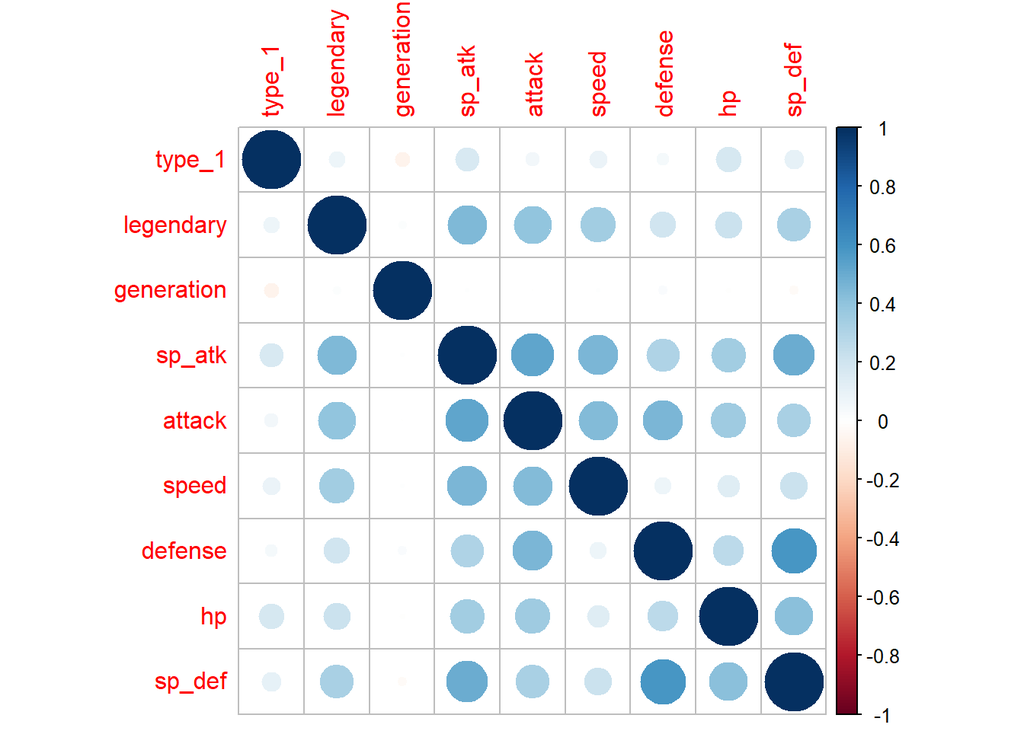

```r
library(corrplot)

Pokemon_reduce_mutate <- select(Pokemon_train, c('type_1','legendary','generation','sp_atk','attack','speed','defense','hp','sp_def')) %>%
  mutate_if(is.character, as.factor) %>%
  mutate_if(is.factor, as.numeric)

M <- cor(Pokemon_reduce_mutate)

corrplot(M)
```

### Exercise 3

First, set up a decision tree model and workflow. Tune the `cost_complexity` hyperparameter. Use the same levels we used in Lab 7 – that is, `range = c(-3, -1)`. Specify that the metric we want to optimize is `roc_auc`.

```r
pruned_tree_spec <- decision_tree() %>%
  set_engine("rpart") %>%
  set_mode("classification")

pruned_tree_fit <- pruned_tree_spec %>%
  fit(formula = type_1 ~ legendary + generation + sp_atk + attack + speed + defense + hp + sp_def, data = Pokemon_train)

pruned_tree_wf <- workflow() %>%
  add_model(pruned_tree_spec %>% set_args(cost_complexity = tune())) %>%
  add_formula(type_1 ~ legendary + generation + sp_atk + attack + speed + defense + hp + sp_def)
```

```r
param_grid <- grid_regular(cost_complexity(range = c(-3, -1)), levels = 10)

pruned_tune <- tune_grid(
  pruned_tree_wf,
  resamples = Pokemon_5fold,
  grid = param_grid,
  metrics = metric_set(roc_auc)
)

save(pruned_tune, file = "HW6_pruned_tune.rda")
```

```r
load(file = "HW6_pruned_tune.rda")
```

Print an `autoplot()` of the results. What do you observe? Does a single decision tree perform better with a smaller or larger complexity penalty?

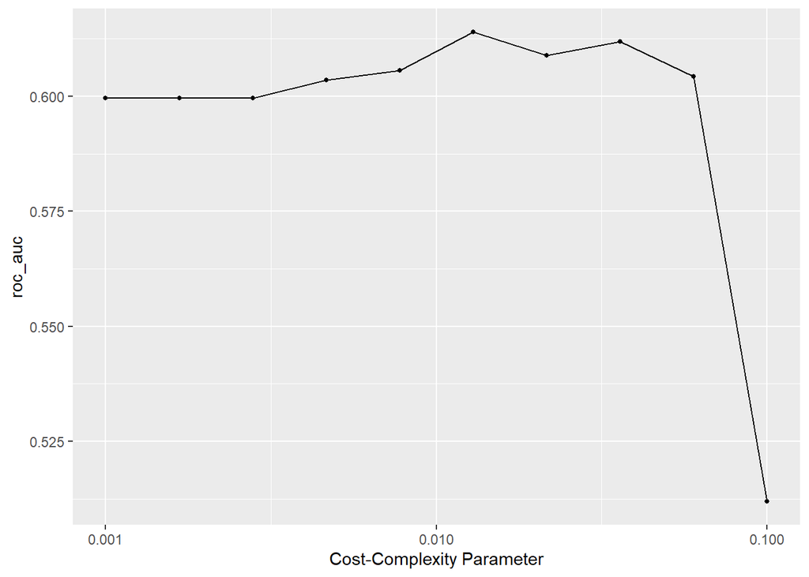

```r
autoplot(pruned_tune)
```

*A single decision tree perform better with a relatively larger complexity penalty. ROC_AUC reaches its maximum at about 0.01.*

### Exercise 4

What is the `roc_auc` of your best-performing pruned decision tree on the folds? *Hint: Use `collect_metrics()` and `arrange()`.*

```r
pruned_tune_metrics <- collect_metrics(pruned_tune) %>%
  arrange(desc(mean))
head(pruned_tune_metrics, 1)
```

```
## # A tibble: 1 x 7
##   cost_complexity .metric .estimator  mean     n std_err .config
##             <dbl> <chr>   <chr>      <dbl> <int>   <dbl> <chr>
## 1          0.0129 roc_auc hand_till  0.614     5  0.0192 Preprocessor1_Model06
```

*The best cost_complexity is 0.012915497 with an roc_auc = 0.6139521.*

### Exercise 5

Using `rpart.plot`, fit and visualize your best-performing pruned decision tree with the *training* set.

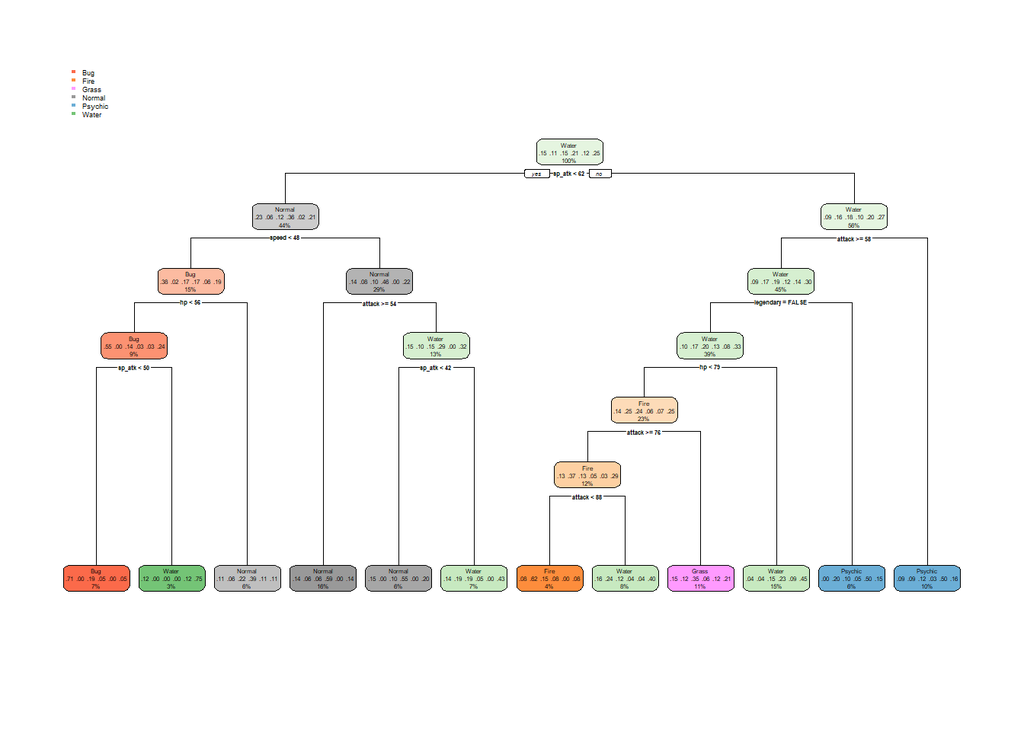

```r
best_complexity <- select_best(pruned_tune)

pruned_tree_final <- finalize_workflow(pruned_tree_wf, best_complexity)

pruned_tree_final_fit <- fit(pruned_tree_final, data = Pokemon_train)

pruned_tree_final_fit %>%
  extract_fit_engine() %>%
  rpart.plot()
```

### Exercise 5

Now set up a random forest model and workflow. Use the `ranger` engine and set `importance = "impurity"`. Tune `mtry`, `trees`, and `min_n`. Using the documentation for `rand_forest()`, explain in your own words what each of these hyperparameters represent.

```r
rf_spec <- rand_forest() %>%
  set_engine("ranger", importance = "impurity") %>%
  set_mode("classification")

rf_wf <- workflow() %>%
  add_model(rf_spec %>% set_args(mtry = tune(), trees = tune(), min_n = tune())) %>%
  add_formula(type_1 ~ legendary + generation + sp_atk + attack + speed + defense + hp + sp_def)
```

*‘mtry’ is the # of independent variables randomly sampled at each split; ‘trees’ is the # of trees to create; ‘min_n’ is the minimum # of data in node before splitting.*

Create a regular grid with 8 levels each. You can choose plausible ranges for each hyperparameter. Note that `mtry` should not be smaller than 1 or larger than 8. **Explain why not. What type of model would `mtry = 8` represent?**

```r
rf_param_grid <- grid_regular(mtry(range = c(1, 8)), trees(range = c(1, 1000)), min_n(range = c(1, 30)), levels = 8)
```

*mtry = 1 meas randomly select one predictor; mtry = 8 means select all predictors.*

### Exercise 6

Specify `roc_auc` as a metric. Tune the model and print an `autoplot()` of the results. What do you observe? What values of the hyperparameters seem to yield the best performance?

```r
# rf_tune <- tune_grid(
#   rf_wf,
#   resamples = Pokemon_5fold,
#   grid = rf_param_grid,
#   metrics = metric_set(roc_auc)
# )
#
# This takes forever to run because there are too many combinations if we use
# (range=c(1:x)) for every hyperparameters.
# So I reset the grid and only set a couple different values
# for trees and min_n as shown below.

rf_tune <-
  rf_wf %>%
  tune_grid(
    resamples = Pokemon_5fold,
    grid = expand.grid(
      mtry = c(1:8),
      trees = c(30, 50, 70, 100, 200, 500),
      min_n = c(5, 10, 15, 20, 25, 30)),
      metrics = metric_set(roc_auc)
  )

save(rf_tune, file = "HW6_rf_tune.rda")
```

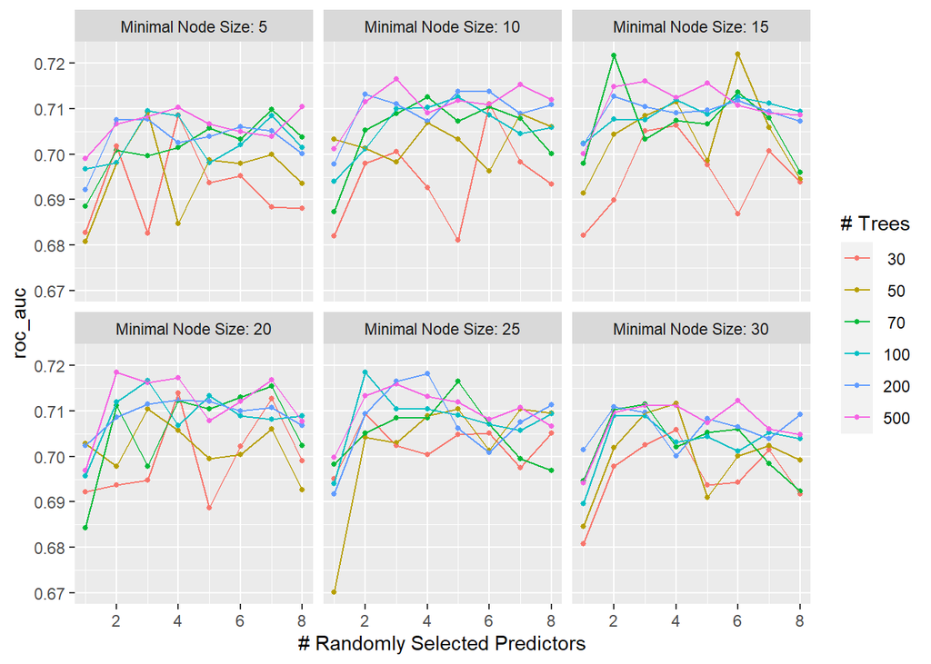

```r
load(file = "HW6_rf_tune.rda")
autoplot(rf_tune)
```

*From the plots, (mtry = 6, trees = 50, min_n = 15) and (mtry = 2, trees = 70, min_n = 15) seem to yield the best performance.*

### Exercise 7

What is the `roc_auc` of your best-performing random forest model on the folds? *Hint: Use `collect_metrics()` and `arrange()`.*

```r
rf_tune_metrics <- collect_metrics(rf_tune) %>%
  arrange(desc(mean))
head(rf_tune_metrics, 1)
```

```
## # A tibble: 1 x 9
##    mtry trees min_n .metric .estimator  mean     n std_err .config
##   <int> <dbl> <dbl> <chr>   <chr>      <dbl> <int>   <dbl> <chr>
## 1     6    50    15 roc_auc hand_till  0.722     5  0.0140 Preprocessor1_Model1~
```

*(mtry = 6, trees = 50, min_n = 15) does yield the best performance with a roc_auc of 0.7221157.*

### Exercise 8

Create a variable importance plot, using `vip()`, with your best-performing random forest model fit on the *training* set.

Which variables were most useful? Which were least useful? Are these results what you expected, or not?

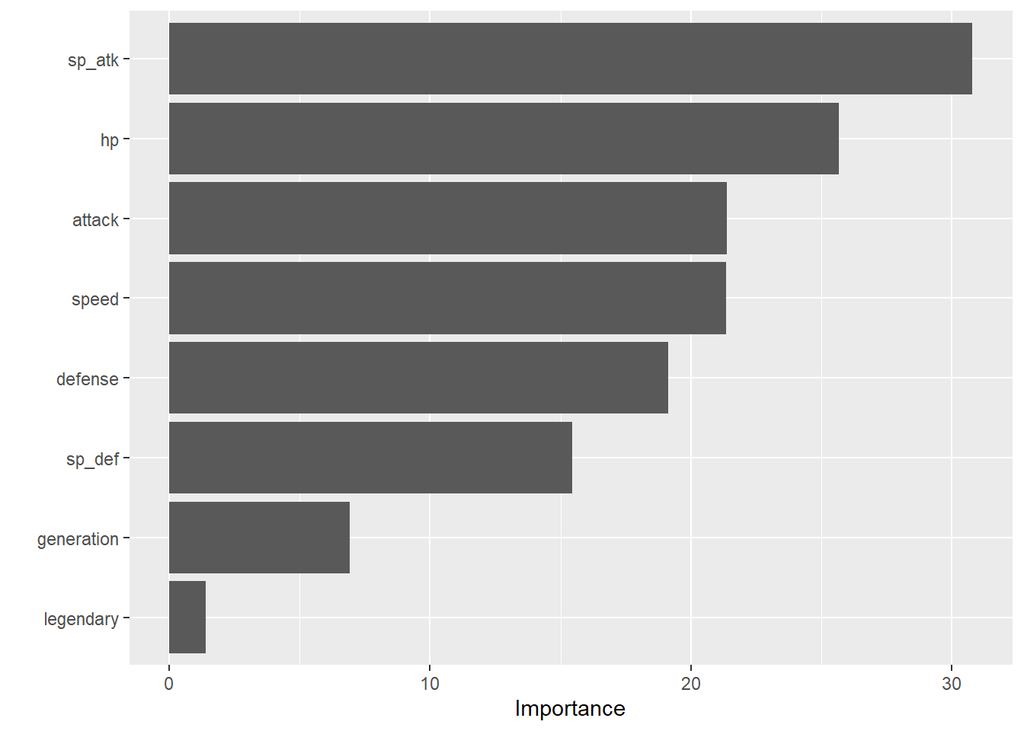

```r
rf_spec_final <- rand_forest(mtry = 6, trees = 50, min_n = 15) %>%
  set_engine("ranger", importance = "impurity") %>%
  set_mode("classification")
rf_fit <- fit(rf_spec_final, type_1 ~ legendary + generation + sp_atk + attack + speed + defense + hp + sp_def, data = Pokemon_train)
vip(rf_fit)
```

*Pokemon’s battle stats are more useful, while their generation and legendary class are least useful. It is what I expected although I considered generation to be the least useful.*

### Exercise 9

Finally, set up a boosted tree model and workflow. Use the `xgboost` engine. Tune `trees`. Create a regular grid with 10 levels; let `trees` range from 10 to 2000. Specify `roc_auc` and again print an `autoplot()` of the results.

```r
bt_spec <- boost_tree() %>%
  set_engine("xgboost") %>%
  set_mode("classification")

bt_wf <- workflow() %>%
  add_model(bt_spec %>% set_args(trees = tune())) %>%
  add_formula(type_1 ~ legendary + generation + sp_atk + attack + speed + defense + hp + sp_def)

bt_param_grid <- grid_regular(trees(range = c(10, 2000)), levels = 10)

bt_tune <- tune_grid(
  bt_wf,
  resamples = Pokemon_5fold,
  grid = bt_param_grid,
  metrics = metric_set(roc_auc)
)
save(bt_tune, file = "HW6_bt_tune.rda")
```

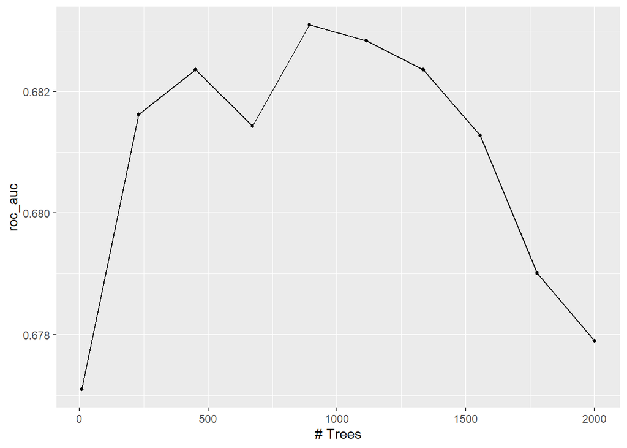

```r
load(file = "HW6_bt_tune.rda")
autoplot(bt_tune)
```

What do you observe? *The model roc_auc reaches its maximum at around 850 trees. It almost looks like a bell curve but there is a dent (decrease in roc_auc) at around 700 tress.*

What is the `roc_auc` of your best-performing boosted tree model on the folds? *Hint: Use `collect_metrics()` and `arrange()`.*

```r
bt_tune_metrics <- collect_metrics(bt_tune) %>%
  arrange(desc(mean))
head(bt_tune_metrics, 1)
```

```
## # A tibble: 1 x 7
##   trees .metric .estimator  mean     n std_err .config
##   <int> <chr>   <chr>      <dbl> <int>   <dbl> <chr>
## 1   894 roc_auc hand_till  0.683     5  0.0103 Preprocessor1_Model05
```

*The highest roc_auc is 0.6830970 at 894 trees.*

### Exercise 10

Display a table of the three ROC AUC values for your best-performing pruned tree, random forest, and boosted tree models. Which performed best on the folds?

```r
t <- matrix(c(max(pruned_tune_metrics$mean), max(rf_tune_metrics$mean), max(bt_tune_metrics$mean)), ncol=1, nrow=3)
colnames(t) <- c('Best ROC-AUC')
rownames(t) <- c('pruned tree','random forest','boosted tree')
as.table(t)
```

```
##               Best ROC-AUC
## pruned tree      0.6139521
## random forest    0.7221157
## boosted tree     0.6830970
```

*Random forest performs the best on the folds.*

Select the best of the three and use `select_best()`, `finalize_workflow()`, and `fit()` to fit it to the *testing* set.

```r
best_penalty <- select_best(rf_tune, metric = "roc_auc")
rf_wf_final <- finalize_workflow(rf_wf, best_penalty)
rf_fit_final <- fit(rf_wf_final, data = Pokemon_test)
rf_fit_final_test <- augment(rf_fit_final, new_data = Pokemon_test)
```

Print the AUC value of your best-performing model on the testing set. Print the ROC curves. Finally, create and visualize a confusion matrix heat map.

```r
ROCAUC_final <- roc_auc(data = rf_fit_final_test, truth = type_1, estimate = c(.pred_Bug, .pred_Fire, .pred_Grass, .pred_Normal, .pred_Psychic, .pred_Water))
ROCAUC_final
```

```
## # A tibble: 1 x 3
##   .metric .estimator .estimate
##   <chr>   <chr>          <dbl>
## 1 roc_auc hand_till      0.984
```

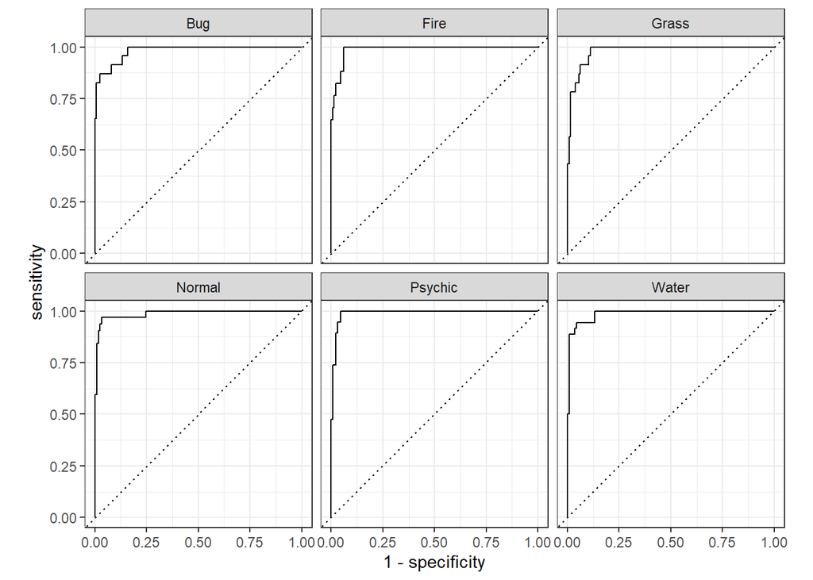

```r
ROC_Curve <- roc_curve(data = rf_fit_final_test, truth = type_1, estimate = c(.pred_Bug, .pred_Fire, .pred_Grass, .pred_Normal, .pred_Psychic, .pred_Water))
autoplot(ROC_Curve)
```

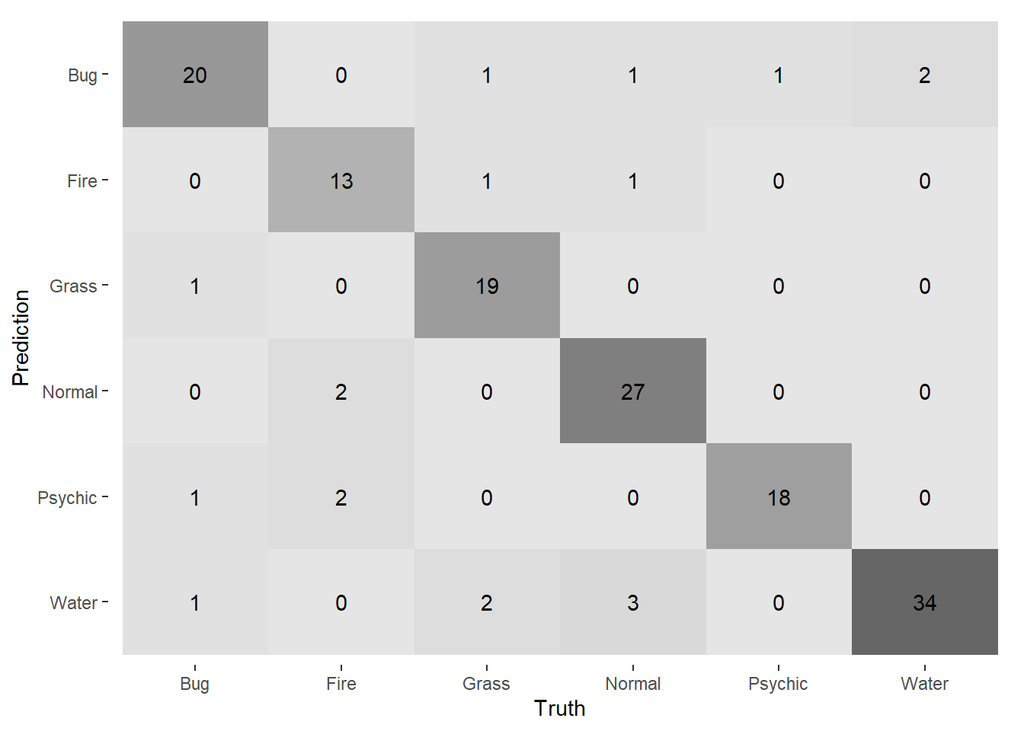

```r
CONF_MAT <- conf_mat(data = rf_fit_final_test, truth = type_1, estimate = .pred_class)
autoplot(CONF_MAT, type = "heatmap")
```

Which classes was your model most accurate at predicting? Which was it worst at?